# Summarizing and Visualizing Data I

# Data Basics

## Data Matrices

**Definition: Cases and Variables**

In any dataset, such as a sample, the objects or individuals measured in the dataset are referred to as **cases**, and the characteristics measured on each case are referred to as the **variables** in the dataset.

**Definition: Data Matrix**

The most straightforward way to inspect data is in a **data matrix**, which is a table with a row for each case and a column for each variable. The cells of the matrix record the value of each variable in each case.

## Data Matrices

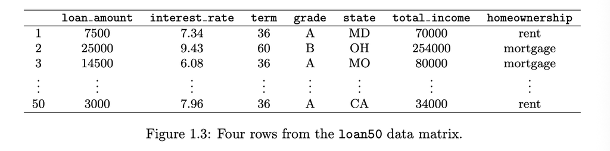

A data matrix from section 1.2.1 of the textbook

**Discussion Question**

What do you think the cases are in this dataset?

## Types of Variables

Variables may be categorized into groups.

**Definition: Numerical Variables**

A **numeric variable** is one that takes a number as its value and can be interpreted as a quantity. (E.g. if $X$ is a numerical variable, it is meaningful to say that case 1’s value of $X$ is 20% larger than case 2’s value of $X$.) A numeric variable is **discrete** if there are jumps between its possible values, and **continuous** if any number within a range is possible.

## Types of Variables

**Examples:**

- Continuous: Sprint times in the Olympics
- Continuous: Percentage of the population with a college degree
- Discrete: Score by the home team in a baseball game
- Discrete: Dry weight of coffee grounds measured to the nearest tenth of a gram

## Types of Variables

**Definition: Categorical Variables**

When the possible values of a variable are categories/labels, we say that a variable is a **categorical variable**. The possible values of a categorical variable are referred to as its **levels**. Sometimes, the levels of a categorical variable are naturally ordered, in which case we call the variable **ordinal**.

**Examples:**

- Categorical: State of residence
- Ordinal: Letter grades

## Numerical or Categorical?

**Discussion Question**

Can you think of a variable where the values are numbers, but it is more natural to say that the variable is categorical rather than numerical?

# Visualizing Categorical Data

## (Contingency) Tables

**Definition: Contingency Table**

The simplest way to summarize a categorical variable is in a table that counts the number of cases for each level of the variable. This can be extended to two categorical variables, where the rows of the table represent the levels of one variable and the columns the levels of the other. This results in a **contingency table** where each cell counts the number of cases corresponding to each *pair* of levels.

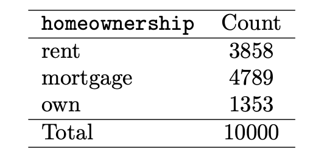

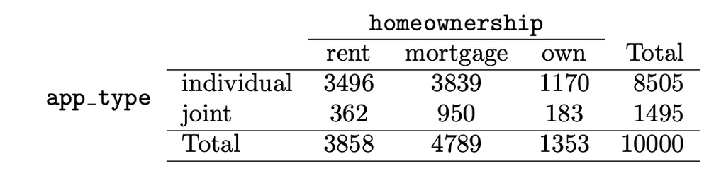

## (Contingency) Tables

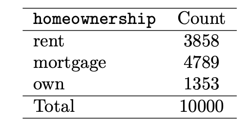

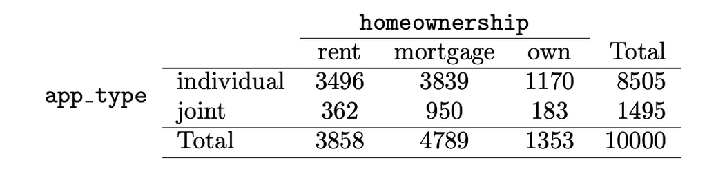

**Discussion Question**

What numbers should be consistent across these two tables?

## More Contingency Tables

Sometimes contingency tables show proportions rather than counts.

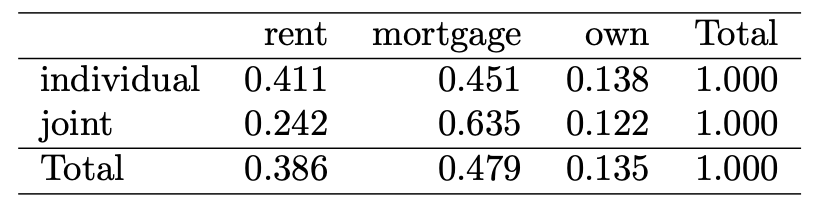

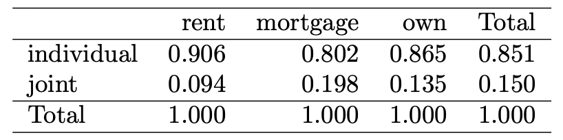

**Discussion Question**

These two contingency tables compare the same two categorical variables. Why do the numbers in the tables differ? In each table, what are the proportions *of*?

## Bar Graphs

**Definition: Bar Graphs**

**Bar graphs** are the visual equivalent of tables: They show the number or proportion of cases corresponding to each level of a categorical variable, using the height of bars to represent amounts.

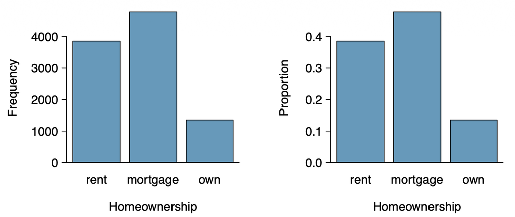

## Side-by-Side and Stacked Bar Graphs

**Definition: Side-by-Side and Stacked Bar Graphs**

Bar graphs can be modified to visualize two categorical variables at a time. For each level of the first variable, a **side-by-side bar graph** displays a bar for every level of the second variable. On the other hand, a **stacked bar graph** instead divides the bars for each level of the first variable into segments for each level of the second variable.

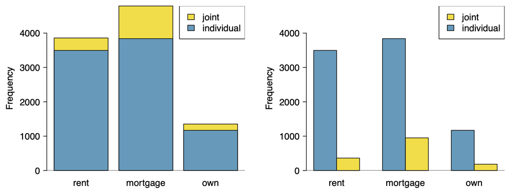

## Side-by-Side and Stacked Bar Graphs

**Discussion Question**

Consider the following two questions:

1. Among applicants with a mortgage, how many more are applying individually than jointly?
2. Among applicants applying jointly, how many more have a mortgage rather than rent?

Using the bar graphs on the previous slide, which of these is easier to answer?

# Visualizing Numerical Data

## Visualizing Discrete and Continuous Data

For discrete data, we can sometimes use bar plots.

**Example:** Number of classes taken in a semester by Wake Forest students

- Not many possible values
- Easy to make a bar showing the number of students for each observed number of classes

## Visualizing Discrete and Continuous Data

**Discussion Question**

Suppose our data are times for the 100 meter sprint in the Olympics across many years. With very rare exceptions, the times are completely unique — no value occurs twice. What problems might we run into if we try to make a bar plot from this data?

## Visualizing Continuous Data

One simple trick to make bar plots work for continuous data:

Force the data to be discrete by *binning it*

**Example:** For a 100 meter sprint, we could bin the data by rounding the data to the nearest 10th of a second.

## Histograms

**Definition: Histogram**

A histogram is created by

1. Creating bins of equal width (e.g. a tenth of a second)
2. Calculating the number or proportion of data points in each bin
3. Drawing a bar over each bin with height equal to calculated number/proportion

## Example: Interest Rates

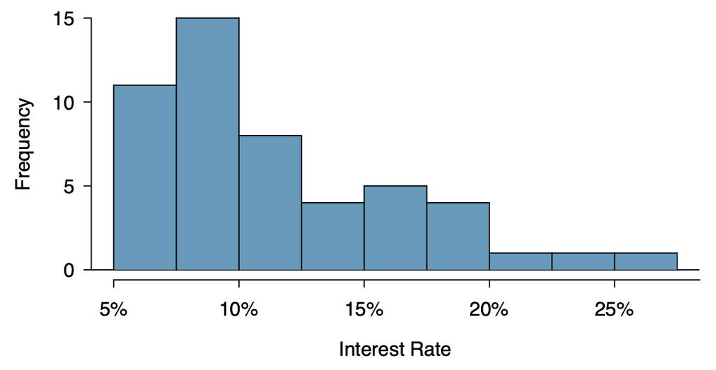

## Histograms

**Discussion Question**

Can you explain why there are no gaps between the bars of a histogram, unlike a bar graph?

## Histograms

**Important**

Unlike bar graphs, histograms depend on the *width of the bins* used for the data, and these are freely chosen by the person making the graph. Therefore, there is no such thing as *the histogram* for a continuous variable.

**Discussion Question**

What do you think goes wrong if we make the bins too wide? What if we make them too narrow?

## Describing Histograms

We have the following terms for describing histograms:

- The bins usually decrease in height at one or both ends of the histogram. The smaller bins at either end of a histogram are called the left and right *tails*.
- If a histogram is asymmetric and has a longer right tail than left tail, we say it is **right skewed**. In the opposite case, we say it is **left skewed**. If neither tail is much longer than the other, we say the histogram is **symmetric**.
- Any prominent peak in a histogram is referred to as a **mode**. If there is one, two, or more modes, we say the histogram is unimodal, bimodal, or multimodal, respectively.